# BellaBeat Report

2022-10-26

## BellaBeat Data Set

This Data set required to understand the behavior of consumers and their smart devices (Non-BellaBeat). Further, we are required to select one Bellabeat product and apply insights gained.

## Summary of Averages

- Avg steps = 7519
- Avg Active Hours = 3.75
- Avg sedentary Hours = 16.7
- Avg Calories = 2282

## Preliminary Observations

- Weight/BMI data was Incomplete/Missing
- 33 Unique consumers
- Only 8 provided BMI/Weight Data
- Only 14 provided heartrate Data
- Only 24 provided sleep Data
- “Active time” is a sum of Very Active, Fairly Active, and Lightly Active time

## Average Number of Steps

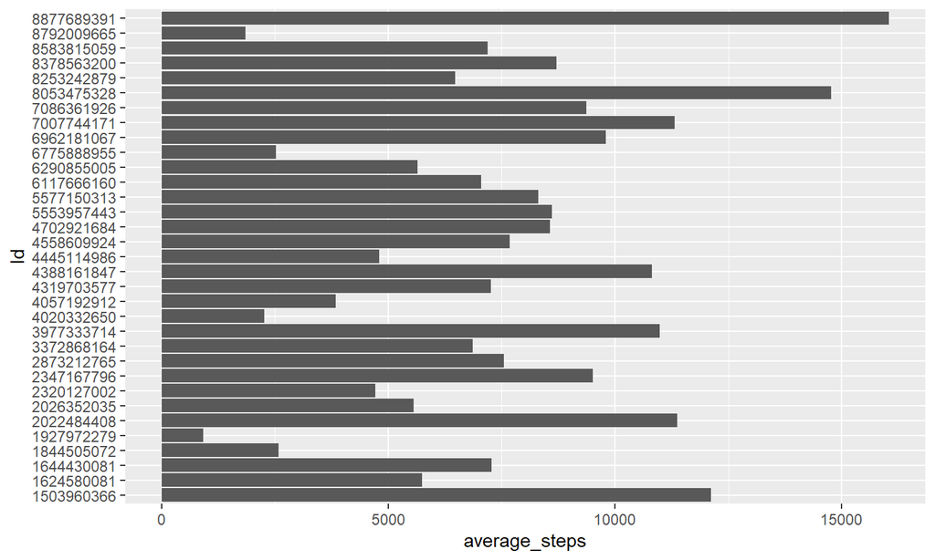

## Active vs. Sedentary Time

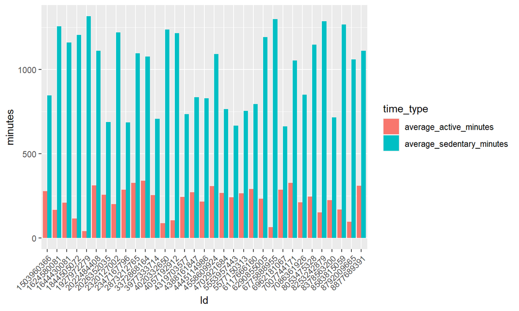

## Active vs. Sedentary Time 2

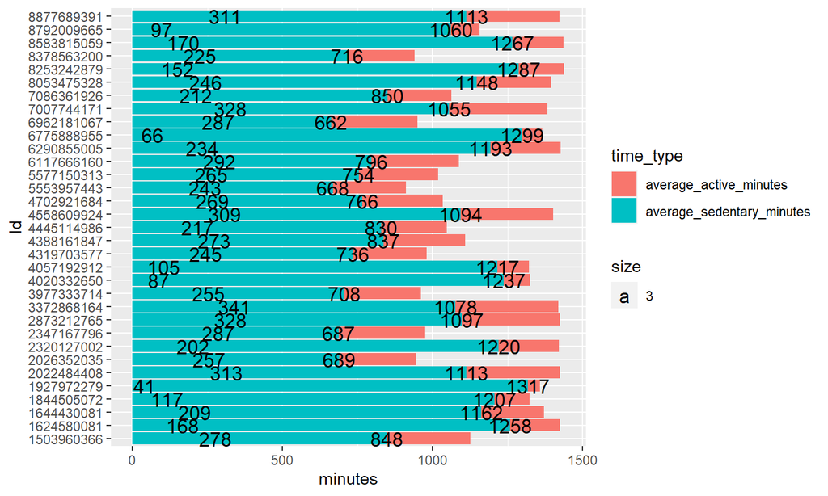

## Deductions

- There is a large difference between active time and sedentary time, more than twice as much sedentary time as all types of active time combined
- Manually input of data produces incomplete results (weight) because not everyone inputs BMI/Weight Data
- 9 people take their devices off during sleep (for comfort or to recharge)
- Most People are under 8,000 steps per day
- Average Hours of sleep/night for all consumers is about 7 Hours

## Recommendations

- Motivate users to input weight data
- Motivate users to get in the habit of going to sleep for more time
- Present users with a pair of devices so that one can charge while the other is being worn to minimize data omission - Motivate users to be more active/not sedentary (any type of activity)
- Motivation can be through notifications, vibrations, reminders, goals/targets on the connected app